# レポート課題第9回

'todoufuken.csv'のデータに対して「最短距離法」と「ウォード法」の二種類の階層クラスタリングを行い，クラスタリング結果の違いに対する考察を行え。

学籍番号：2094572t  
氏名：木澤 祐人

Googleドライブのマウントとフォルダの移動

```python
from google.colab import drive
drive.mount('/content/drive')
# フォルダの移動には"%cd"を使用します。
# 作業フォルダへ移動
%cd /content/drive/'My Drive'/情報管理/09/
# 現在のフォルダの中身を表示
%ls
```

```
/content/drive/My Drive/情報管理/09
09_01_hierarchical_clustering.ipynb  convert_report.ipynb  todoufuken.csv
car.csv                              report09.ipynb
```

必要ライブラリをインポート。  
日本語フォントもダウンロードとインポート。

```python
import pandas as pd
import numpy as np
import matplotlib.pyplot as plt
!pip install japanize-matplotlib
import japanize_matplotlib
```

```
     |████████████████████████████████| 4.1 MB 14.2 MB/s
```

`todoufuken.csv`を読み込む。  
このデータは各都道府県の代表駅の東経と北緯を記録したデータである。  
東経と北緯のデータをXとして，都道府県の位置をクラスタリングする。

```python
# pandas の関数 read_csv を用いた csvファイル読み込み
csv_data = pd.read_csv('todoufuken.csv', encoding='SHIFT-JIS')
# データの前半部(.headで取得できる)のみ表示
display(csv_data.head())

# numpy用データ(ndarray型) に変換する。
X = csv_data.loc[:,'東経':'北緯'].to_numpy()

# 各サンプルの都道府県をサンプルの名前とする。
labels = csv_data.loc[:,'都道府県'].to_list()

# データのサンプル数と次元数を得る。
(num_samples, num_dimensions) = np.shape(X)
print('Nunber of samples: ' + str(num_samples))
print('Number of dimensions: ' + str(num_dimensions))
```

|  | 都道府県 | 計測地点 | 東経 | 北緯 |
| --- | --- | --- | --- | --- |
| 0 | 北海道 | 札幌駅 | 141.350778 | 43.068611 |
| 1 | 青森 | 青森駅 | 140.734692 | 40.828853 |
| 2 | 岩手 | 盛岡駅 | 141.136361 | 39.701667 |
| 3 | 宮城 | 仙台駅 | 140.879750 | 38.260139 |
| 4 | 秋田 | 秋田駅 | 140.129747 | 39.716842 |

```
Nunber of samples: 47
Number of dimensions: 2
```

データの標準化とプロットを行う。

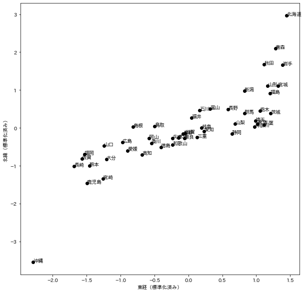

```python
# データの標準化
X_norm = (X - np.mean(X, axis=0)) / np.std(X, axis=0)

# 二次元データのプロット
plt.figure(figsize=(10,10))
plt.scatter(X_norm[:,0], X_norm[:,1], color='k')
plt.xlabel('東経（標準化済み）')
plt.ylabel('北緯（標準化済み）')

# 各サンプルの名前(ラベル)を付ける
for n in range(num_samples):
  label = str(labels[n])
  plt.annotate(label, (X_norm[n,0], X_norm[n,1]))

plt.show()
```

## 小問1: このデータに対して最短距離法を適用し，挙動を確認せよ。

まず初期状態として、各サンプルをそれぞれクラスとして扱うため、 以下のようにリストを使って定義する。

```python
# クラスを空のリストとして定義
initial_class_list = []

# 各サンプルのデータを initial_class_list に追加（append関数）していく
for n in range(num_samples):
  initial_class_list.append(np.array([X_norm[n]]))
```

次に、ユークリッド距離を計算する関数を以下に定義する。  
$d({\mathbf x}, {\mathbf y})=\sqrt{\sum_{d=1}^{D}(x_{d}-y_{d})^{2}}$  
（$x_{d}$はベクトル$\mathbf x$の$d$次元目の要素。$D$はベクトルの次元数。）

```python
def euclidean_distance(x, y):
  '''
      ユークリッド距離を計算して出力する
      x, y: 距離を測りたい2個の多次元ベクトル
  '''
  dist = np.sum((x-y)**2)
  dist = np.sqrt(dist)
  return dist
```

続いて，クラス1とクラス2の最短距離を計算する関数を以下に定義する。  
${\rm shortest\_dist}({\mathbf c}_1, {\mathbf c}_2) = \min_{{\mathbf x}_1 \in {\mathbf c}_1, {\mathbf x}_2 \in {\mathbf c}_2} d({\mathbf x}_1, {\mathbf x}_2)$

```python
def get_shortest_distance(class1, class2):
  '''
      クラス1(class1)とクラス2(class2)の最短距離を計算
      class1: NxDの配列(N:クラス1に属するデータのサンプル数, D:次元)
      class2: MxDの配列(M:クラス2に属するデータのサンプル数)
  '''
  # クラス1のサンプル数Nと次元数Dを得る
  N, D = np.shape(class1)
  # クラス2のサンプル数Mと次元数Dを得る
  M, D = np.shape(class2)

  # 距離マトリクスを作成
  # dist_matrix[n,m]にはクラス1に属するn番目のサンプルと
  # クラス2に属するm番目のサンプルとの距離が格納される
  dist_matrix = np.zeros([N, M])
  for n in range(N):
    for m in range(M):
      dist_matrix[n, m] = euclidean_distance(class1[n], class2[m])

  # 最短距離を求める
  min_dist = np.min(dist_matrix)

  return min_dist
```

以上で定義した関数を用いて、最短距離法による階層クラスタリングを行い、  
そのクラスの結合過程を、分割数ごとにアニメーションにして表示すると次のようになる。

```python
from matplotlib import animation, rc
from IPython.display import HTML


# クラスの初期状態をコピー
class_list = initial_class_list.copy()
# color_list はクラス毎のプロット時の色を定義するリスト
color_list = []
for n in range(num_samples):
  color_list.append(0)

# アニメーション用
images = []
fig = plt.figure(figsize=(8,8))
cmap = plt.cm.get_cmap('tab20').colors #20色のカラーマップ

while True:
  # 現在のクラス数を取得
  num_classes = len(class_list)
  # プロット
  image_tmp = []
  for k in range(num_classes):
    # k番目のクラスデータを得る
    class_data = class_list[k]
    # 色の決定
    c_ind = color_list[k] % 20
    c_ind = 2*(c_ind % 10) + (c_ind // 10)
    if c_ind == 0:
      color = 'k'
    else:
      color = cmap[c_ind]
    # プロット
    img = plt.scatter(class_data[:,0], class_data[:,1], color=color)
    image_tmp.append(img)
  img = plt.text(1.0, 2.5, 'Num of classes: '+str(num_classes), size='x-large')
  image_tmp.append(img)
  images.append(image_tmp)

  # クラス数が 1 になっていれば終了
  if num_classes == 1:
    break

  # 最も近いクラスのペアを見つける。
  min_dist = 9999999
  min_i = 0
  min_j = 0
  for i in range(num_classes - 1):
    for j in range(i+1, num_classes):
      # クラスi とクラスj の距離を計算
      dist = get_shortest_distance(class_list[i], class_list[j])

      if dist < min_dist:
        # 距離の最小値を更新
        min_dist = dist
        min_i = i
        min_j = j

  # classes[min_i]とclasses[min_j]を統合する。
  new_class = np.vstack([class_list[min_i], class_list[min_j]])
  # 統合したクラスをクラスリストの末尾に追加
  class_list.append(new_class)

  # 統合したクラスの色を決める
  if color_list[min_i] == 0 and color_list[min_j] == 0:
    new_color = max(color_list) + 1
  elif color_list[min_i] != 0 and color_list[min_j] != 0:
    new_color = min([color_list[min_i], color_list[min_j]])
  else:
    new_color = max([color_list[min_i], color_list[min_j]])
  color_list.append(new_color)

  # 統合に使われたクラスを削除する。
  del(class_list[min_j])
  del(class_list[min_i])
  del(color_list[min_j])
  del(color_list[min_i])

plt.xlabel('東経（標準化済み）')
plt.ylabel('北緯（標準化済み）')

# アニメーション作成
anim = animation.ArtistAnimation(fig, images, interval=1000)

# Google Colaboratoryの場合必要
rc('animation', html='jshtml')
plt.close()
display(anim)
```

[figure not shown]

Once Loop Reflect

## 小問2: ウォード法による階層クラスタリングを実装し，その挙動を確認せよ。クラス分割数$K=6$のときのクラスタリング結果を図示せよ。

ヒント

- `get_shortest_distance`関数の要領で，ウォード法による距離を返す関数 `get_ward_distance`を作成する。
- クラス統合を繰り返すループ内にて，`dist = get_shortest_distance(class_list[i], class_list[j])`を`dist = get_ward_distance(class_list[i], class_list[j])`に変更する。
- [デバッグ情報] sklearnライブラリのAgglomerativeClusteringモジュールを使って実装した場合の結果を以下に示す。自分で実装した結果が合っているかの確認に利用してもらいたい。**課題はsklearnライブラリを使用せずに実装すること！**

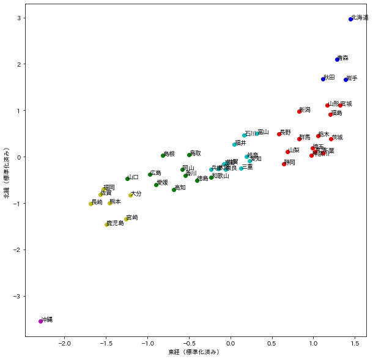

```python
from sklearn.cluster import AgglomerativeClustering
model = AgglomerativeClustering(affinity='euclidean',linkage='ward', n_clusters=6)

model = model.fit(X_norm)


colors = ['r', 'b', 'g', 'c', 'm', 'y']
# 二次元データのプロット
plt.figure(figsize=(10,10))
# セントロイドを"x"印でプロット
for k in range(6):
  c = colors[k%6] # プロットの色を，クラス番号によって自動的に変える。
  plt.scatter(X_norm[model.labels_==k,0], X_norm[model.labels_==k,1], color=c)
plt.xlabel('東経（標準化済み）')
plt.ylabel('北緯（標準化済み）')

# 各サンプルの名前(ラベル)を付ける
for n in range(num_samples):
  label = str(labels[n])
  plt.annotate(label, (X_norm[n,0], X_norm[n,1]))

plt.show()
```

## 以下、解答部分

```python
# クラスを空のリストとして定義
initial_class_list = []

# 各サンプルのデータを initial_class_list に追加（append関数）していく
for n in range(num_samples):
  initial_class_list.append(np.array([X_norm[n]]))
```

続いて、クラス1とクラス2のウォード法による距離を計算する関数を以下に定義する。  
${\rm ward\_dist}({\mathbf c}_1, {\mathbf c}_2) = \sum_{{\mathbf x}_{12} \in {\mathbf c}_{12}} |{\mathbf x}_{12} - \bar{\mathbf x}_{12}|^2 - \sum_{{\mathbf x}_1 \in {\mathbf c}_1} |{\mathbf x}_1 - \bar{\mathbf x}_1|^2 - \sum_{{\mathbf x}_2 \in {\mathbf c}_2} |{\mathbf x}_2 - \bar{\mathbf x}_2|^2$

```python
def get_ward_distance(class1, class2):
  '''
      クラス1(class1)とクラス2(class2)のウォード法による距離を計算
      class1: NxDの配列(N:クラス1に属するデータのサンプル数, D:次元)
      class2: MxDの配列(M:クラス2に属するデータのサンプル数)
  '''
  # クラス1のサンプル数Nと次元数Dを得る
  N, D = np.shape(class1)
  # クラス2のサンプル数Mと次元数Dを得る
  M, D = np.shape(class2)

  class12 = np.vstack([class1, class2])
  s12 = np.sum((N + M) * np.var(class12, axis=0))

  s1 = np.sum(N * np.var(class1, axis=0))
  s2 = np.sum(M * np.var(class2, axis=0))

  return s12 - s1 - s2
```

以上で定義した関数を使って、階層クラスタリングを行う。  
ここでは、クラス数が $K=6$ になるまで統合を繰り返す。

```python
K = 6

# クラスの初期状態をコピー
class_list = initial_class_list.copy()

while True:
  # 現在のクラス数を取得
  num_classes = len(class_list)

  # クラス数が K になっていれば終了
  if num_classes == K:
    break

  # 最も近いクラスのペアを見つける。
  min_dist = 9999999
  min_i = 0
  min_j = 0
  for i in range(num_classes - 1):
    for j in range(i+1, num_classes):
      # クラスi とクラスj の距離を計算
      class_i = class_list[i]
      class_j = class_list[j]
      dist = get_ward_distance(class_i, class_j)

      if dist < min_dist:
        # 距離の最小値を更新
        min_dist = dist
        min_i = i
        min_j = j

  # 今，最も近いクラスのペアは min_i番目と min_j番目のクラスである。
  # これらを統合する。

  # classes[min_i]とclasses[min_j]を統合する。
  new_class = np.vstack([class_list[min_i], class_list[min_j]])

  # 統合したクラスをクラスリストの末尾に追加
  class_list.append(new_class)

  # 統合に使われたクラスを削除する。
  # (min_j > min_i のため，先にmin_iを削除するとインデクスがずれる。よってmin_jを先に削除してからmin_iを削除する)
  del(class_list[min_j])
  del(class_list[min_i])
```

結果をプロットする。

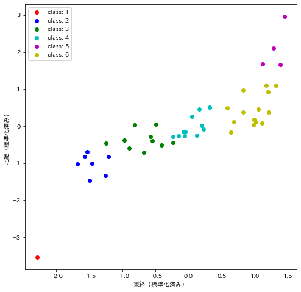

```python
colors = ['r', 'b', 'g', 'c', 'm', 'y']
# 二次元データのプロット
plt.figure(figsize=(8,8))


for k in range(K):
  c = colors[k%6] # プロットの色を，クラス番号によって自動的に変える。

  # k番目のクラスデータを得る
  class_data = class_list[k]
  # プロット
  plt.scatter(class_data[:,0], class_data[:,1], color=c, label='class: '+str(k+1))
plt.xlabel('東経（標準化済み）')
plt.ylabel('北緯（標準化済み）')
plt.legend()
plt.show()
```

クラスの結合過程を、分割数ごとにアニメーションにして表示すると次のようになる。

```python
from matplotlib import animation, rc
from IPython.display import HTML


# クラスの初期状態をコピー
class_list = initial_class_list.copy()
# color_list はクラス毎のプロット時の色を定義するリスト
color_list = []
for n in range(num_samples):
  color_list.append(0)

# アニメーション用
images = []
fig = plt.figure(figsize=(8,8))
cmap = plt.cm.get_cmap('tab20').colors #20色のカラーマップ

while True:
  # 現在のクラス数を取得
  num_classes = len(class_list)
  # プロット
  image_tmp = []
  for k in range(num_classes):
    # k番目のクラスデータを得る
    class_data = class_list[k]
    # 色の決定
    c_ind = color_list[k] % 20
    c_ind = 2*(c_ind % 10) + (c_ind // 10)
    if c_ind == 0:
      color = 'k'
    else:
      color = cmap[c_ind]
    # プロット
    img = plt.scatter(class_data[:,0], class_data[:,1], color=color)
    image_tmp.append(img)
  img = plt.text(1.0, 2.5, 'Num of classes: '+str(num_classes), size='x-large')
  image_tmp.append(img)
  images.append(image_tmp)

  # クラス数が 1 になっていれば終了
  if num_classes == 1:
    break

  # 最も近いクラスのペアを見つける。
  min_dist = 9999999
  min_i = 0
  min_j = 0
  for i in range(num_classes - 1):
    for j in range(i+1, num_classes):
      # クラスi とクラスj の距離を計算
      dist = get_ward_distance(class_list[i], class_list[j])

      if dist < min_dist:
        # 距離の最小値を更新
        min_dist = dist
        min_i = i
        min_j = j

  # classes[min_i]とclasses[min_j]を統合する。
  new_class = np.vstack([class_list[min_i], class_list[min_j]])
  # 統合したクラスをクラスリストの末尾に追加
  class_list.append(new_class)

  # 統合したクラスの色を決める
  if color_list[min_i] == 0 and color_list[min_j] == 0:
    new_color = max(color_list) + 1
  elif color_list[min_i] != 0 and color_list[min_j] != 0:
    new_color = min([color_list[min_i], color_list[min_j]])
  else:
    new_color = max([color_list[min_i], color_list[min_j]])
  color_list.append(new_color)

  # 統合に使われたクラスを削除する。
  del(class_list[min_j])
  del(class_list[min_i])
  del(color_list[min_j])
  del(color_list[min_i])

plt.xlabel('東経（標準化済み）')
plt.ylabel('北緯（標準化済み）')

# アニメーション作成
anim = animation.ArtistAnimation(fig, images, interval=1000)

# Google Colaboratoryの場合必要
rc('animation', html='jshtml')
plt.close()
display(anim)
```

[figure not shown]

Once Loop Reflect

## 小問3: 最短距離法とウォード法の挙動を見比べ，どういった点が異なるか，また何故そのような違いが出るのかについて考察せよ。

【補足】  
階層型クラスタリングの様子をアニメーションにする場合，都道府県名のラベルは表示させないようにしてください。  
つまり，以下のコードは不要です．

```
# 各サンプルの名前(ラベル)を付ける
for n in range(num_samples):
  label = str(labels[n])
  plt.annotate(label, (X_norm[n,0], X_norm[n,1]))
```

（`09_01_hierarchical_clustering.ipynb` からアニメーションを作成する部分をそのままコピペすれば，都道府県は表示されません。）  
都道府県名を表示させた状態でアニメーションを作成した場合，`convert_report.ipynb`を使ってHTMLファイル化した際に容量オーバーとなってアニメーションが表示されなくなる不具合があるためです。

### 考察

それぞれの方法のアニメーションによる結果における、同じ分割数に分割された状態でどのような差が生じているかに着目する。  
初めはそれほど大きな差は無いものの、分割数が33になった付近で徐々に違いが現れ始め、  
29の時点では、結合により前者が7個・後者が12個のクラスができていることが分かり、後者の方が一つのクラスに属するサンプルが少なくなっている。  
分割数が18付近になってくるとその差はより顕著になっており、結合済みのクラス数の差は大きくなっている。また、違いはクラスに属するサンプルの広がりにも見え始めており、前者の緑・橙の分布に比べ、後者の方が全体的にまとまって分布しているように見える。  
両者の違いは未結合のサンプルに着目することでも確認できる。  
北海道と沖縄を除く45サンプル全てが少なくとも1回結合するクラス数は、前者が5・後者が16であった。

以上のような違いが生ずる主な要因は、  
後者が結合した場合に最も分散が小さくなるようなクラスを結合するのに対し、  
前者はクラス間の距離をある１組のサンプル間距離のみで評価するため、各クラス全体の広がりが一切考慮されない点にあると考えられる。

これにより前者では、  
クラス内の1点が、ある別のクラスの1点と近いだけで、  
2つのクラスの他の点の分布や、それ以外のクラスの分布に関係なくクラスの結合が行われていき、  
結果として、サンプル数が多く、かつ分散の大きなクラスが生じるのである。